# Método de Metropolis - Random Walk para amostragem

2022-09-11

## Integração de Monte Carlo

## O Método de Monte Carlo

- A integração de Monte Carlo é um método de integração numérica que se baseia na geração de números aleeatórios para aproximação dos valores de integrais definidas;
- De maneira simplificada, o método pretende estimar a área de uma função \(f\) a partir de uma outra função \(g\), que possui área facilmente calculável. É gerada uma sequência de pontos pertencentes à \(g\) e a proporção desses pontos que também pertencerem à \(f\) será a área estimada dessa função.

## O Método de Monte Carlo

- Formalmente, o método de Monte Carlo é definido como:
- Seja \(\theta = \int_{a}^{b}f(x)dx\). Estima-se \(\theta\) a partir da seguinte relação:
- \(\theta = \int_{a}^{b}g(x)h(x) dx\)
- \(\theta = (b-a)\int_{a}^{b}g(x)\frac{1}{b-a}dx\)
- \(\hat{\theta} = (b-a)E[g(X)]\)
- Onde \(X \sim U(a,b)\).

## O Método de Monte Carlo

- Computacionalmente, temos o seguinte passo-a-passo:
  - Gera-se uma sequência \(X_1,X_2,\cdots,X_n\) de \(U(a,b)\);
  - Calcula-se \(g(x) = \frac{1}{n}\sum_{i=1}^{n}g(x_i)\);
  - \(\hat{\theta}=(b-a)g(x)\).
- Com isso, podemos estimar numericamente as probabilidades de uma Variável Aleatória a partir de uma amostra da distribuição de interesse;
- O problema que pode ocorrer é caso tal distribuição não possa ser amostrada.

## Monte Carlo por Cadeias de Markov

## Algoritmos de Metropolis-Hastings

- Para remediar as situações em que temos uma função densidade de probabilidade complicada que **podemos calcular**, mas que não podemos amostrar, utilizamos os algoritmos de Metropolis-Hastings;
- Esses algoritmos tem como base cadeias de Markov e suas propriedades de convergência para uma **distribuição estacionária \(\pi\)**, dado que certas condições de regularidade sejam satisfeitas.

## Algoritmos de Metropolis-Hastings

- Portanto, dada a função de probabilidade de \(f\), queremos construir uma cadeia de Markov que possui \(f\) como sua distribuição estacionária;
- Disso, iremos amostrar uma sequência de valores \(\{x_n\}\) da cadeia gerada, que irá convergir em distribuição para a função de densidade \(f\).

## Cadeias de Markov

- Uma sequência de variáveis aleatórias \(\{X_1,X_2,\ldots,X_n\}\) com probabilidades de transição entre os estados \(P[X_t|X_{t-1},X_{t-2},\ldots,X_1]=P[X_t|X_{t-1}]\) é chamada de Cadeia de Markov, onde a probabilidade de ir para o próximo estado depende somente do estado atual da cadeia;
- As probabilidades de transição podem ser organizadas em uma matriz \(P_{n \times n}\), chamada **matriz de transição** dessa cadeia, com \(P[X_{t+1} = j|X_{t}=i]=P_{ij}\);
- Dada uma distribuição inicial dos estados \(\pi_{0}\), podemos encontrar a distribuição de probabilidade dos estados após uma iteração será \(\pi_{1}=\pi_0P\).

## Cadeias de Markov

- Com isso, podemos encontrar a **distribuição estacionária \(\pi_e\)** da cadeia de Markov por meio da relação \(\pi_e=\pi_eP\), ou seja, não importa onde a cadeia começar, ela eventualmente irá convergir para a distribuição estacionária, dado que as seguintes condições sejam satisfeitas:
  - A cadeia seja **homogênea** (as probabilidades de transição são invariantes);
  - A cadeia seja **irredutível** (todos os estados podem ser “atingidos” saindo-se de quaisquer outros estados em um tempo finito);
  - A cadeia seja **aperiódica** (o período de todos os estados da cadeia é igual a 1).

## Teorema ergódico

- Com isso, se a cadeia é aperiódica, a distribuição estacionária também será a distribuição limite, no sentido de que a distribuição limite de \(\{X_t\}\) será \(\pi_e\) dado qualquer valor do estado inicial \(X_0\), chamada a **propriedade ergódica** da cadeia;
- Essa propriedade é de grande interesse nos algoritmos de Metropolis-Hastings, pois eventualmente atingiremos a distribuição alvo, que é a distribuição estacionária;
- Portanto, para qualquer função \(f\) teremos que:
  - \(\frac{1}{T}\sum_{t=1}^{T}f(X_t)=E_\pi[h(X)]\), ou seja, a média dos valores gerados pela cadeia é um estimador consistente para a média da distribuição teórica.

## Metropolis-Hastings

- Com isso, a ideia dos algoritmos de Metropolis-Hastings é gerar uma cadeia \(\{X_t,t=0,1,2,\ldots\}\) de forma que sua distribuição estacionária seja a distribuição alvo \(f\);
- O algoritmo especifica para um dado estado \(X_t\) como gerar o próximo estado \(X_{t+1}\), a partir de um valor candidato \(Y\), gerado por uma função proposta \(g(\cdot|X_t)\), e caso tal valor candidato:
  - seja **aceito**, a cadeia se move para \(Y\) no tempo \(t+1\) e \(X_{t+1}=Y\);
  - seja **rejeitado**, a cadeia permanece em \(X_{t}\) no tempo \(t+1\) e \(X_{t+1}=X_{t}\).

## Metropolis-Hastings

- A regra geral de aceitação do algoritmo para os valores gerados é dada por:
- \(\alpha(X_t|Y)=\min(\frac{f(Y)g(X_t|Y)}{f(X_t)g(Y|X_t)},1\)
- A escolha da distribuição proposta deve satisfazer algumas condições de regularidade para que sua distribuição limite seja a distribuição alvo \(f\). Geralmente, funções com o mesmo suporte da distribuição alvo irão satisfazer tais condições.

## Metropolis *Random-Walk*

## *Random-Walk*

- Um passeio aleatório, ou *random walk* é uma equação recursiva (iterativa), onde uma observação no tempo \(t+1\) depende apenas do estado no tempo \(t\) mais um “erro”, ou seja: \(x_{t+1}=x_t+\epsilon\), com \(\epsilon \sim g\), com \(g\) sendo uma distribuição simétrica;
- Podemos escrever esse processo iterativo como uma diferença sucessiva \(x_{t+1}-x_{t}=\epsilon\);
- Ou seja, conhecendo \(x_t\), a distribuição de \(x_{t+1}\) será uma função de \(\epsilon\), ou seja \(g( x_{t+1}|x_t)=g(\epsilon)\);
- Como \(g\) é simétrica, temos que \(g(x_{t}|x_{t+1})=g(-\epsilon) = g(\epsilon)\).

## *Random-Walk*

Exemplo de um *random walk* com função \(g\sim N(0,1)\)

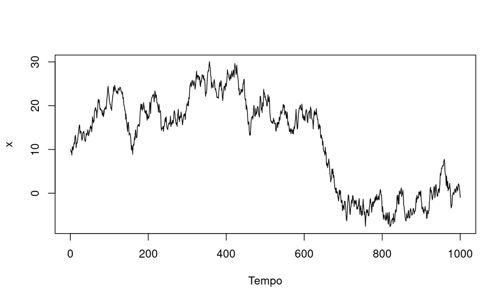

## Metropolis *Random-Walk*

- Dessa forma, se um valor candidato \(Y = X_{t+1}\) é gerado a partir de uma distribuição proposta simétrica, então a probabilidade de a cadeia se mover de \(X_t\) para \(X_{t+1}\) depende apenas da distância entre eles, ou seja \(g(X_{t+1}|X_t)=g(|X_{t+1}-X_t|)\);
- Logo, a cada iteração, um incremento \(Z\) é gerado a partir de \(g\) e \(Y=X_t+Z\);
- Tal incremento pode por exemplo ser uma Normal da forma \(Y|X_t\sim N(X_t,\sigma^2)\), para algum \(\sigma^2>0\), ou uma Uniforme no intervalo \((-\delta,\delta)\).

## Passo-a-passo do algoritmo Metropolis *Random-Walk*

- Propõe-se uma função \(g\) simétrica;
- Define-se um valor inicial \(X_0\) pertencente ao domínio de \(f\);
- Repete-se até chegar na distribuição estacionária:
  - Gera-se um valor candidato \(Y = X_{t+1}=X_t+Z\);
  - Gera-se \(U\) de uma \(U(0,1)\);
  - Calcula-se a taxa de aceitação \(\alpha(X_t,Y)=\min(\frac{f(Y)}{f(X_t)},1)\);
  - Se \(U\le \alpha(X_t,Y)\), aceita-se \(Y\) e \(X_{t+1}=Y\), caso contrário \(X_{t+1}=X_t\).

## Exemplos do algoritmo

## Normal a partir de uma Uniforme

- Seja o caso em que queremos amostrar de uma distribuição Normal padrão utilizando o algoritmo de Metropolis *random-walk*, usando como função proposta uma Uniforme \(U(-\delta,\delta)\);
  - Simula-se um \(z\sim U(-\delta,\delta)\) e faz-se \(Y = X_t+Z\);
  - Calcula-se a taxa de aceitação \(\alpha(X_t,Y) = \min(\frac{f(Y)}{f(X_t)},1)\), onde \(f\) é a Normal Padrão;
  - Simule \(u \sim U(0,1)\). Se \(u \le \alpha(X_t,Y)\), então \(X_{t+1}=Y\), senão \(X_{t+1}=X_t\).

## Normal a partir de uma Uniforme

Os primeiros 1000 passos da cadeia gerada utilizando \(X_0=0\) e \(\delta=1\):

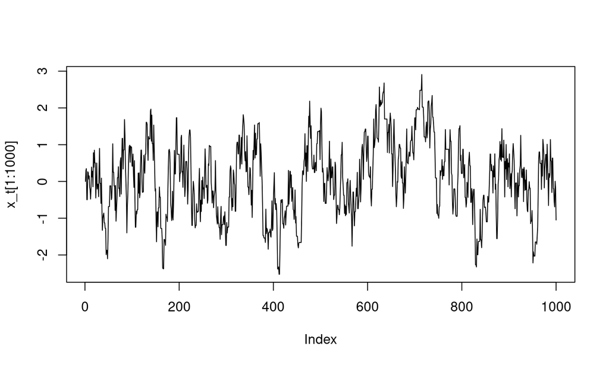

## Histograma do Algoritmo

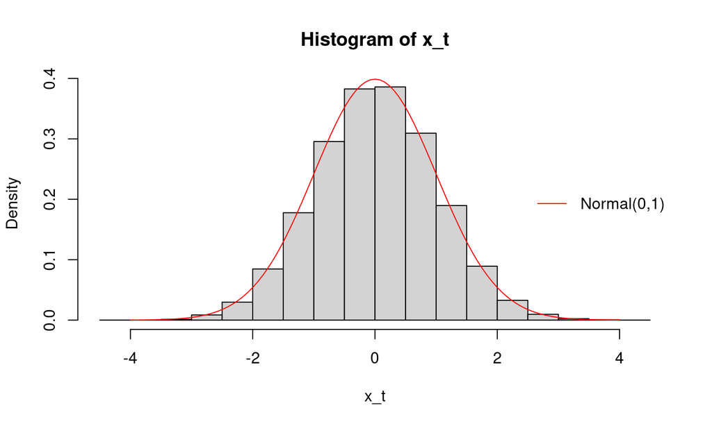

## Função arbitrária

- Seja uma variável aleatória \(X\) que segue a função densidade de probabilidade \(f(x) =k|\cos(x)|e^{-|x|}\), \(x\in \mathbb{R}\). Queremos amostrar dessa densidade utilizando o algoritmo de Metropolis *random-walk* e uma função proposta \(N(X_t,\sigma^2)\);
- \(k\) é a constante de integração para que a integral da função seja 1 e é desconhecida. Porém, não é necessário conhecê-la para o algoritmo de Metropolis *random-walk*, uma vez que podemos estimá-lo.

## Gráfico da função

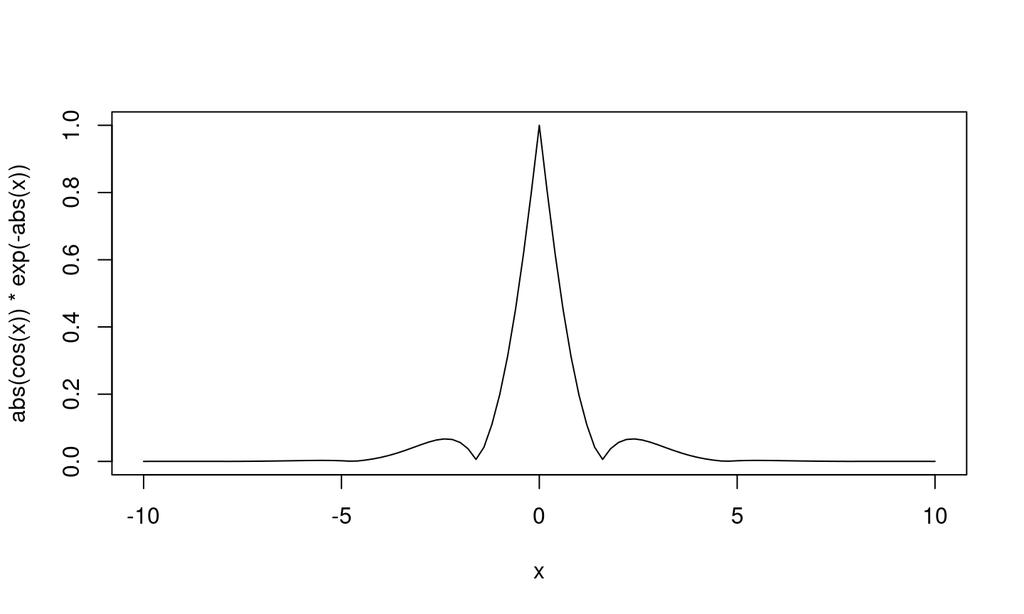

## Algoritmo

Primeiros 1000 passos para \(X_0=0\) e \(\sigma\) variável:

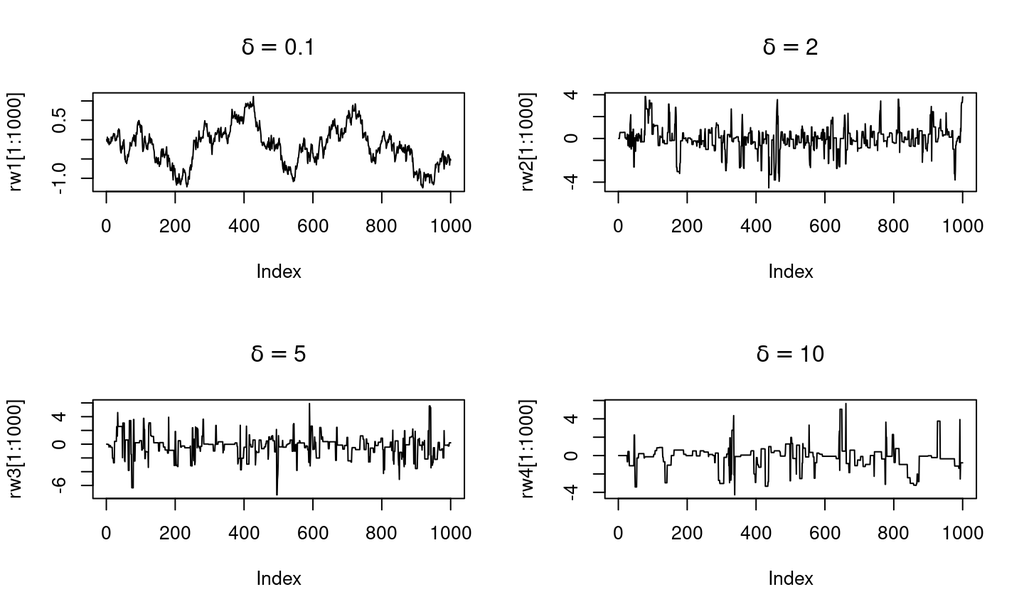

## Algoritmo

Primeiros 1000 passos para \(X_0=10\) e \(\sigma\) variável:

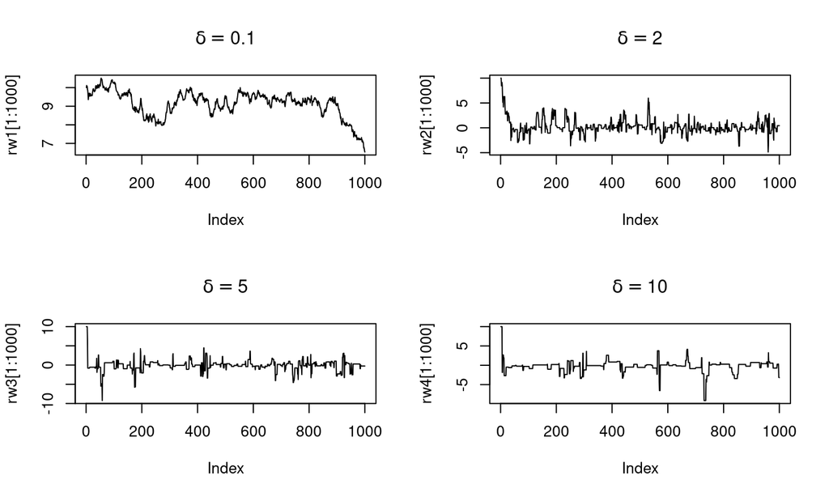

## Histograma

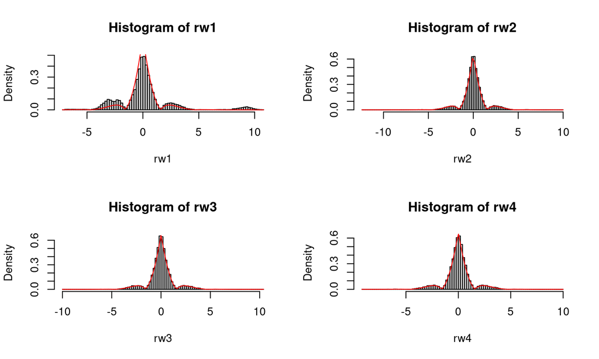

## Função densidade acumulada

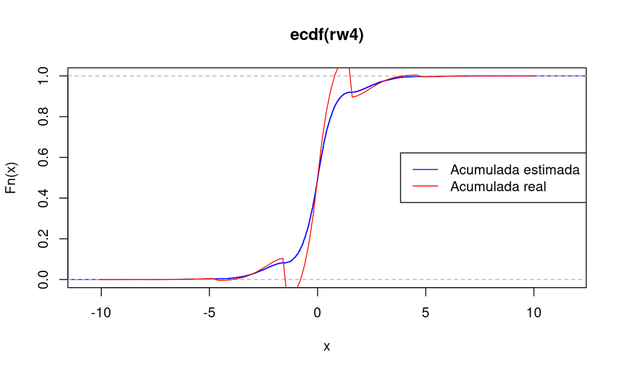

## Correlação entre os valores da cadeia

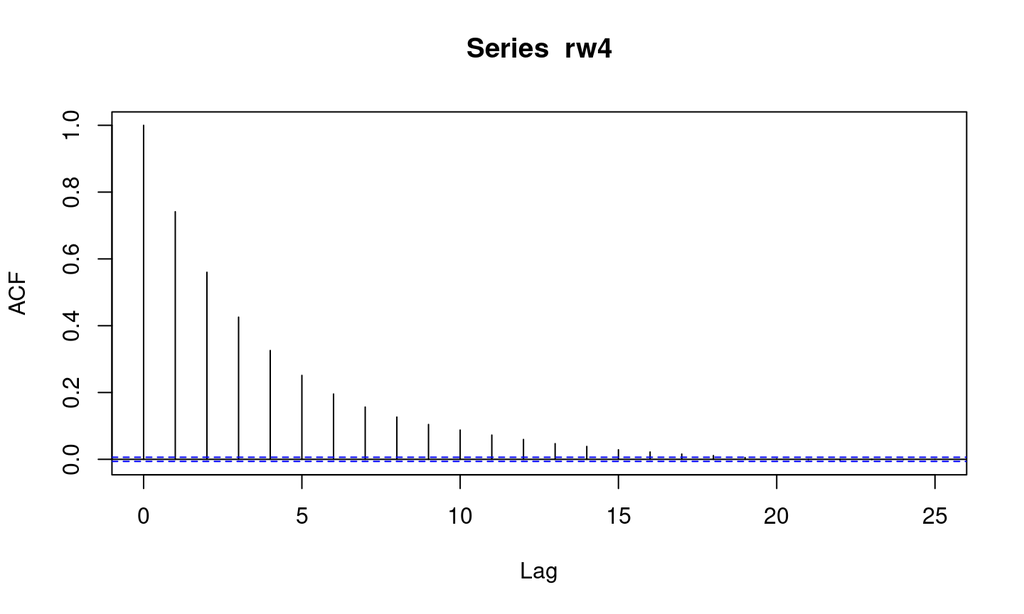